# report

Yongsheng Li

## Introduction

```r
params <- c("S:/Researcher Projects/Self Service Analysis Projects/10017_USCDAT/Yongsheng Li/",
            "O:/Datasets/10017_USCDAT/v01/10017_USCDAT_v01_20210609_2220_formats.csv",
            "O:/Datasets/10017_USCDAT/v01/10017_USCDAT_v01_20210609_2220_analytic_data.csv",
            "O:/Datasets/10017_USCDAT/uscdat_oshpd_formats.csv",
            "O:/Datasets/10017_USCDAT/uscdat_oshpd.csv")
setwd(params[1])

library(dplyr)
library(data.table)
library(ggplot2)
library(mlr3)
library(xgboost)
library(scales)
library(stringr)
library(caret)
library(reshape2)
library(mlr)
library(tidyr)
library(pROC)
```

```r
# reading in data types for survey data
data_types_file <- read.csv(file = params[2],
                            na.strings = "",
                            colClasses = "character")

# reading in data types for hospitalization data
oshpd_data_types_file <- read.csv(file = params[4],
                                  na.strings = "",
                                  colClasses = "character")

# creating a named character vector to use in assigning character and Date types for survey data
data_types <- data_types_file[, 2]
names(data_types) <- data_types_file[, 1]
data_types <- data_types[data_types=="character" | data_types=="Date"]

# creating a named character vector to use in assigning Date types for hospitalization data
oshpd_data_types <- oshpd_data_types_file[, 2]
names(oshpd_data_types) <- oshpd_data_types_file[, 1]
oshpd_data_types <- oshpd_data_types[oshpd_data_types=="Date"]

# reading in survey data and assigning data types
analytic_data <- read.csv(file = params[3],
                          na.strings = "",
                          colClasses = data_types)

# reading in hospitalization data file
oshpd_data <- read.csv(file = params[5],
                       na.strings = "")

# converting date fields
oshpd_data[names(oshpd_data_types)] <- lapply(oshpd_data[names(oshpd_data_types)], as.Date, "%m/%d/%Y")

# dropping columns that already exist in analytic_data
oshpd_data[c("date_of_birth_dt", "date_of_death_dt", "cause_of_death_cde", "cause_of_death_dsc",
             "qnr_1_fill_dt", "qnr_2_fill_dt", "ses_quartile_ind", "first_moveout_ca_dt")] <- list(NULL)

# joining survey data and hospitalization data on participant_key
combined_data <- inner_join(analytic_data, oshpd_data,by = "participant_key") # n = 132538
```

## Data cleaning.

### variable selection and exclusion by hand checking

There are so many variables in the dataset. We exclude some useless or bad variables by hand checking and then group the remaining variables for simplicity and intuition. The following variables are excluded:

- cause_of_death_dsc: This variables indicate so much information about our target variable, which may cause data leakage to machine learning models, thus excluded.
- qnr_1/2/3/4/5/6_(mini)_fill_dt: questionaire filling dates are not useful
- diag_icd_dsc, diag_ccs, proc_icd_dsc, proc_ccs: text description variables are excluded since we donot to intend text mining in this project
- study_start_date_q3, analysis_end_date: not related with the objective

The remaining variables are selected for downstream analysis.

```r
# participant_key used as the rowname
# g1: basic characteristics of the patient: age, diet, weight, smoke, alchol, etc
g1 = c("age_at_baseline","participant_race","menarche_age","fullterm_age1st",
       "preg_ever_q1","preg_total_q1","meno_stattype","height_q1","weight_q1","bmi_q1",
       "allex_hrs_q1","allex_life_hrs","stand_hrs","sit_hrs","sleep_hrs","vit_reg_no",
       "diet_plant","diet_highprotfat","diet_highcarb","dief_ethnic","diet_saladwine",
       "vit_mulvit_q1","serv_fats_q1","alchl_g_dayrecen","alchl_analyscat","smoke_lifeexpo",
       "smoke_statcat","smoke_expocat","passmok_expocat","smoke_totyrs","smoke_totpackyrs",
       "smoke_yrs_quit","cig_day_avg","shsmok_any")

# g2: some date variables to be transformed and then excluded
g2 = c("date_of_birth_dt","date_of_death_dt","hysterectomy_dt","bilateral_mastectomy_dt",
       "bilateral_oophorectomy_dt","first_moveout_ca_dt")

# g3: related to community and population
g3 = c("ses_quartile_ind","blockgroup90_urban_cat","adopted",
       "twin","nih_ethnic_cat","birthplace","birthplace_mom","birthplace_dad",
       "age_mom_atbirth","age_dad_atbirth","near_oilrefine")

# g4: some important clinical characteristics such as surgery and drug history
g4 = c("cause_of_death_cde","hysterectomy_ind","bilateral_mastectomy_ind","bilateral_oophorectomy_ind",
       "oralcntr_ever_q1","oralcntr_yrs","brca","mammo_ever_q1","hbpmed_totyrs",
       "nsaid_totyrs","endoca_self_q1","cervca_self_q1","ovryca_self_q1","lungca_self_q1",
       "leuk_self_q1","hodg_self_q1","colnca_self_q1","thyrca_self_q1","meln_self_q1",
       "diab_self_q1","stroke_self_q1","hrtatk_self_q1","hbp_self_q1","brca_selfsurvey",
       "asthma_q3","insulin_daily","aceinhb_daily","othhbp_daily","tamox_daily","steroid_daily",
       "brondil_daily","cholmed_daily","antidep_daily")
```

```r
# a participant_key can correspond to multiple hospital visit_ids

# h1: admission and discharge date to be transformed
h1 = c("admission_dt","discharge_dt")

# h2: hospital-related information
h2 = c("length_of_stay_day_cnt","dnr_flg","facility_flg","src_admission_cde",
       "src_site_cde","src_licensure_cde","src_route_cde","major_diag_cat_cde",
       "patient_care_typ","facility_county_cde","facility_zip5_cde","spoken_lang_cde")

# h3: financial and payer information
h3 = c("payer_cat_cde","payer_plan_cde","payer_coverage_typ","total_charges_amt")

# h4~h8: diagnoses and procedures by icd codes, ccs categories, and presence of admission
h4 = c("diag_icd1","diag_icd2","diag_icd3","diag_icd4","diag_icd5")
h5 = c("diag_ccs_code1","diag_ccs_code2","diag_ccs_code3","diag_ccs_code4","diag_ccs_code5")
h6 = c("diag_poa1","diag_poa2","diag_poa3","diag_poa4","diag_poa5")
h7 = c("proc_icd1","proc_icd2","proc_icd3","proc_icd4","proc_icd5")
h8 = c("proc_ccs_code1","proc_ccs_code2","proc_ccs_code3","proc_ccs_code4","proc_ccs_code5")

# deceased is our target variable, 0=No, 1=Yes
```

### excluding invalid records

Some visit records are found to have date of death date earlier than admission date, these are invalid, thus excluded from the data. Some patients died during hospitalization, We also exclude this portion of visit records since our main focus is on risk of death after discharge date.

```r
features = c("participant_key","visit_id",g1,g2,g3,g4,h1,h2,h3,h4,h5,h6,h7,h8,"deceased")
df = combined_data[,features]
df = df[is.na(df$date_of_death_dt)|(df$admission_dt<=df$date_of_death_dt & df$date_of_death_dt>=df$discharge_dt),]
```

### one participant_key, multiple hospital visits

One patient may have multiple hospital visits. As shown in the follwoing graph, Many patients went to more than 1 hospitals, and about 95% of participants went to less than 8 hospitals. Although most of the basic characteristics remain unchanged for a patient, the hospitalization data from different hospitalization visits may differ. In this case, we only use the hospitalization data of the last visit for a patient for accuracy because we think it is the latest for most related to the patients’ death risk.

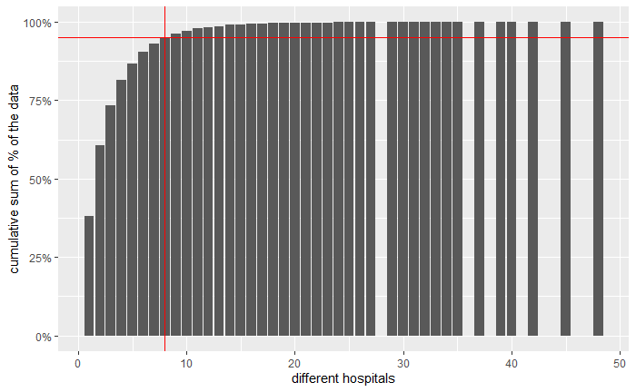

```r
tmp = df[,c("participant_key","visit_id")]
hos_counts = table(tmp$participant_key)
names(hos_counts) = NULL
hos_counts = as.data.frame(hos_counts)
ggplot(hos_counts, aes(x=Freq))+geom_bar(aes(y=cumsum(..count..)/sum(..count..)))+scale_y_continuous(labels=percent)+xlab("different hospitals")+ylab("cumulative sum of % of the data")+geom_hline(yintercept=0.95,color="red")+geom_vline(xintercept=8,color="red")
```

## Exploratory Data analysis

### days to death after discharge date

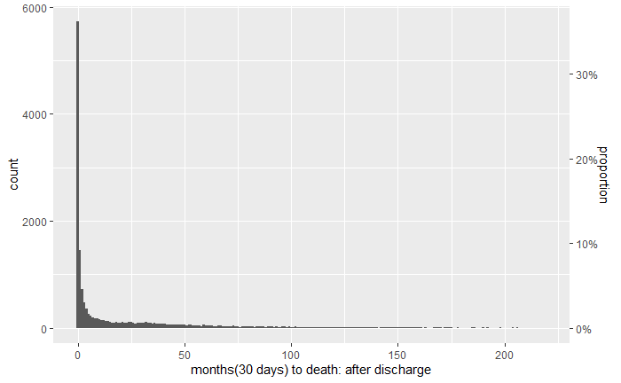

```r
tmp = df[,c("participant_key","visit_id","admission_dt","discharge_dt","date_of_death_dt")]
#tmp$days2death_af_admi = as.numeric(tmp$date_of_death_dt - tmp$admission_dt)
#tmp$days2death_af_disc = as.numeric(tmp$date_of_death_dt - tmp$discharge_dt)
#a= dim(tmp[tmp$days_to_death<30,])[1]
#b= dim(tmp[tmp$days_to_death<=30 & tmp$days_to_death>=0 ,])[1]
#c= dim(tmp[tmp$days_to_death<30 & tmp$days_to_death>0 ,])[1]
#d= dim(tmp[tmp$days_to_death<30 & tmp$days_to_death>=0 ,])[1]
#e= dim(tmp[tmp$days2death_af_admi==0,])[1]
#c(a,b,c,d,e)
tmp = as.data.table(tmp)
tmp = tmp[,.SD[which.max(discharge_dt)],by=participant_key]
tmp$days_to_death = as.numeric(tmp$date_of_death_dt - tmp$discharge_dt)/30
alive_num = dim(tmp[is.na(tmp$days_to_death),])[1]
tmp = tmp[!is.na(tmp$days_to_death),]
dead_num = dim(tmp)[1]
ggplot(tmp, aes(x=days_to_death))+geom_histogram(binwidth=1)+xlab("months(30 days) to death: after discharge")+scale_y_continuous(sec.axis=sec_axis(trans = ~./dead_num,labels = percent, name = "proportion"))
```

```r
#ggplot(tmp[tmp$months_to_death<0,], aes(x=months_to_death))+geom_histogram(binwidth=1)+ xlab("months to death: before discharge")+
#ggplot(tmp[tmp$months_to_death>=0,], aes(x=months_to_death))+geom_histogram(binwidth=1,aes(y=cumsum(..count..)/sum(..count..)))+xlab("months to death: after discharge")+scale_y_continuous(labels=percent)
```

### alive/dead ratio

```r
counts = c(alive_num,dead_num)
counts_name = c("alive_num","dead_num")
for(i in 1:10){
        counts = c(counts, dim(tmp[tmp$days_to_death<=i & tmp$days_to_death>=i-1 ,])[1])
        counts_name = c(counts_name,paste("within_",i*30,"_days",collapse = ""))
}
names(counts) = counts_name
as.data.frame(counts)
```

|  | counts |
| --- | --- |
| alive_num | 28625 |
| dead_num | 15833 |
| within_ 30 _days | 6596 |
| within_ 60 _days | 1023 |
| within_ 90 _days | 624 |
| within_ 120 _days | 422 |
| within_ 150 _days | 330 |
| within_ 180 _days | 249 |
| within_ 210 _days | 233 |
| within_ 240 _days | 168 |

[output cut: 2 more lines]

### seasonal or month-related deaths

We summarized the death counts with respect to each month and to each quater to see if there are any seasonal or month-related deaths. It seems that Q1 has a slightly higher death counts ,and Q3 has a slightly lower death counts. However, Rigorous statistical testing is needed to confirm the relationships.

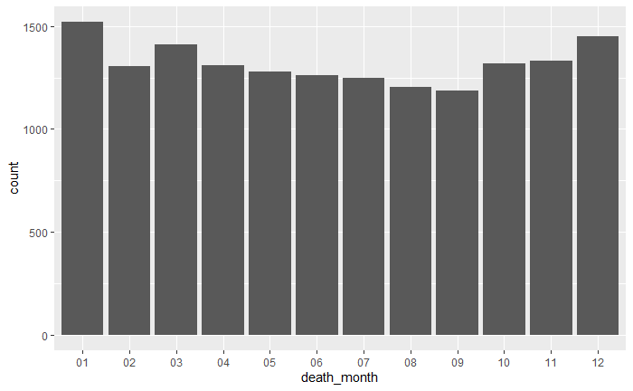

```r
tmp$death_month = str_sub(tmp$date_of_death_dt,6,7)
a = as.Date(cut(as.Date(tmp$date_of_death_dt, "%Y-%m-%d"),"month"))+32
tmp$death_season = factor(quarters(a),levels=c("Q1","Q2","Q3","Q4"),labels=c("Q1","Q2","Q3","Q4"))
ggplot(tmp, aes(x=death_month))+geom_bar()
```

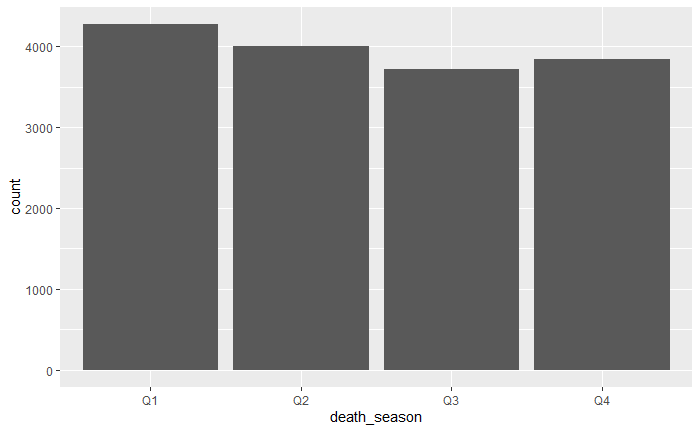

```r
ggplot(tmp, aes(x=death_season))+geom_bar()
```

We can use chi-square test to statistically check if the death are month or season related.

```r
p_month = chisq.test(as.matrix(table(tmp$death_month)))$p.value
p_season = chisq.test(as.matrix(table(tmp$death_season)))$p.value
```

the p-value for month-related checking is 1.0601451^{-12} and is 1.4760301^{-9} for season related checking. Using a threshold of 0.05 we can say that there are indeed month or season realted deaths.

```r
#tmp = df[,c("participant_key","visit_id",h4,"deceased")]
#tmp = tmp[tmp$deceased=="1",]
#tmp = melt.data.table(as.data.table(tmp), id.vars= c("participant_key","visit_id","deceased"),  measure.vars=h4)
#ggplot(tmp, aes(x=))
```

```r
tmp = df
tmp = as.data.table(tmp)
tmp = tmp[,.SD[which.max(discharge_dt)],by=participant_key]
tmp$days_to_death = as.numeric(tmp$date_of_death_dt - tmp$admission_dt)/30
tmp$dead60 = 0
tmp[tmp$days_to_death<60,"dead60"] = 1
```

## Feature transformations

### NA values.

As shown in the following graph, many variables have high proportion of NA values. In this project, we treat NA as a special class of the corresponding variable and incorporate them into the model building.

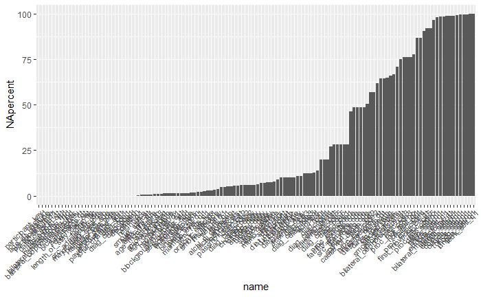

```r
cols = summarizeColumns(tmp)
cols$NApercent =  round(cols$na*100/dim(tmp)[1],2)
cols = cols[order(cols$NApercent),]
cols$name = factor(cols$name, levels = cols$name)
p = ggplot(cols,aes(x=name,y=NApercent))+geom_bar(stat ="identity")+theme(axis.text.x=element_text(angle=45, vjust = 1, hjust=1,size=8))
#ggsave(p,filename = "cols.pdf", dpi=720,width=14)
p
```

### convert categorical variables to one-hot

```r
to_onehot_vars = c()
to_null_vars = c()
#========================transforming g group features====================================

# g1: basci characteristics of the patient: age, diet, weight, smoke, alchol, etc
# g1 = c("age_at_baseline","participant_race","menarche_age","fullterm_age1st",
#        "preg_ever_q1","preg_total_q1","meno_stattype","height_q1","weight_q1","bmi_q1",
#        "allex_hrs_q1","allex_life_hrs","stand_hrs","sit_hrs","sleep_hrs","vit_reg_no",
#        "diet_plant","diet_highprotfat","diet_highcarb","dief_ethnic","diet_saladwine",
#        "vit_mulvit_q1","serv_fats_q1","alchl_g_dayrecen","alchl_analyscat","smoke_lifeexpo",
#        "smoke_statcat","smoke_expocat","passmok_expocat","smoke_totyrs","smoke_totpackyrs",
#        "smoke_yrs_quit","cig_day_avg","shsmok_any")
# age_at_baseline, menarche_age, fullterm_age1st,preg_total_q1,diet_plant,diet_highprotfat
# diet_highcarb,dief_ethnic,diet_saladwine,alchl_g_dayrecen,smoke_lifeexpo,smoke_totyrs,
# smoke_totpackyrs,smoke_yrs_quit,cig_day_avg,

to_onehot_vars = c(to_onehot_vars, "meno_stattype","stand_hrs","sit_hrs","sleep_hrs",
                   "vit_reg_no","vit_mulvit_q1","serv_fats_q1","alchl_analyscat","smoke_statcat",
                   "smoke_expocat","passmok_expocat","passmok_expocat","shsmok_any")

# g2: some date variables to be transformed and then excluded
# g2 = c("date_of_birth_dt","date_of_death_dt","hysterectomy_dt","bilateral_mastectomy_dt",
#        "bilateral_oophorectomy_dt","first_moveout_ca_dt")
tmp[, hysterectomy_age:= as.numeric(hysterectomy_dt - date_of_birth_dt)]
tmp[,bilateral_mastectomy_age:= as.numeric(bilateral_mastectomy_dt - date_of_birth_dt)]
tmp[,bilateral_oophorectomy_age := as.numeric(bilateral_oophorectomy_dt - date_of_birth_dt)]
to_null_vars = c(to_null_vars, g2)


# g3: related to community and population
# g3 = c("ses_quartile_ind","blockgroup90_urban_cat","adopted",
#        "twin","nih_ethnic_cat","birthplace","birthplace_mom","birthplace_dad",
#        "age_mom_atbirth","age_dad_atbirth","near_oilrefine")
tmp[,nih_ethnic_cat := sapply(nih_ethnic_cat, FUN=function(x){strsplit(x,split=":")[[1]][1]})]
to_onehot_vars = c(to_onehot_vars,g3)

# g4: some important clinical characteristics such as surgery and drug history
# g4 = c("cause_of_death_cde","hysterectomy_ind","bilateral_mastectomy_ind","bilateral_oophorectomy_ind",
#        "oralcntr_ever_q1","oralcntr_yrs","brca","mammo_ever_q1","hbpmed_totyrs",
#        "nsaid_totyrs","endoca_self_q1","cervca_self_q1","ovryca_self_q1","lungca_self_q1",
#        "leuk_self_q1","hodg_self_q1","colnca_self_q1","thyrca_self_q1","meln_self_q1",
#        "diab_self_q1","stroke_self_q1","hrtatk_self_q1","hbp_self_q1","brca_selfsurvey",
#        "asthma_q3","insulin_daily","aceinhb_daily","othhbp_daily","tamox_daily","steroid_daily",
#        "brondil_daily","cholmed_daily","antidep_daily")
to_null_vars = c(to_null_vars,"cause_of_death_cde")
to_onehot_vars = c(to_onehot_vars, "hysterectomy_ind","bilateral_mastectomy_ind","bilateral_oophorectomy_ind",
                   "oralcntr_ever_q1", "oralcntr_yrs","brca","mammo_ever_q1","hbpmed_totyrs","nsaid_totyrs",
                   "endoca_self_q1","cervca_self_q1","ovryca_self_q1","lungca_self_q1",
                   "leuk_self_q1","hodg_self_q1","colnca_self_q1","thyrca_self_q1","meln_self_q1",
                   "diab_self_q1","stroke_self_q1","hrtatk_self_q1","hbp_self_q1","brca_selfsurvey",
                   "asthma_q3","insulin_daily","aceinhb_daily","othhbp_daily","tamox_daily","steroid_daily",
                   "brondil_daily","cholmed_daily","antidep_daily")

#========================transforming h group features====================================

# h1: admission and discharge date to be transformed
# h1 = c("admission_dt","discharge_dt")
to_null_vars = c(to_null_vars, h1)

# h2: hospital-related information
# h2 = c("length_of_stay_day_cnt","dnr_flg","facility_flg","src_admission_cde",
#       "src_site_cde","src_licensure_cde","src_route_cde","major_diag_cat_cde",
#       "patient_care_typ","facility_county_cde","facility_zip5_cde","spoken_lang_cde")
# length_of_stay_day_cnt unchanged
to_onehot_vars = c(to_onehot_vars, "dnr_flg","facility_flg","src_admission_cde",
       "src_site_cde","src_licensure_cde","src_route_cde","major_diag_cat_cde",
       "patient_care_typ","facility_county_cde","spoken_lang_cde")
to_null_vars = c(to_null_vars,"facility_zip5_cde" )


# h3: financial and payer information
# h3 = c("payer_cat_cde","payer_plan_cde","payer_coverage_typ","total_charges_amt")
# total_charges_amt unchanged
to_onehot_vars = c(to_onehot_vars,"payer_cat_cde","payer_plan_cde","payer_coverage_typ")


# h4~h8: diagnoses and procedures by icd codes, ccs categories, and presence of admission
# h4 = c("diag_icd1","diag_icd2","diag_icd3","diag_icd4","diag_icd5")
# h5 = c("diag_ccs_code1","diag_ccs_code2","diag_ccs_code3","diag_ccs_code4","diag_ccs_code5")
# h6 = c("diag_poa1","diag_poa2","diag_poa3","diag_poa4","diag_poa5")
# h7 = c("proc_icd1","proc_icd2","proc_icd3","proc_icd4","proc_icd5")
# h8 = c("proc_ccs_code1","proc_ccs_code2","proc_ccs_code3","proc_ccs_code4","proc_ccs_code5")
to_null_vars = c(to_null_vars, h4,h7 )
to_null_vars = c(to_null_vars, c("participant_key", "visit_id", "deceased", "days_to_death"))
to_onehot_vars = c(to_onehot_vars, h5,h6,h8)
tmp = tmp[,!to_null_vars, with=FALSE]

#=========== transforming to onehot variables =======================

for(each in to_onehot_vars){
        print(each)
        eval( parse(text=paste0("tmp$",each,' = paste0("',each,"_\",tmp$",each,")")) )
        eval( parse(text=paste0('tmp = dcast.data.table(data=tmp, ...~ ',each,',length, value.var = "',each,'")')) )
}
setnames(tmp, colnames(tmp), gsub("[-*]","",colnames(tmp)))
tmp[,dead60:=factor(dead60)]
colnames(tmp)[467] = "spoken_lang_cde__star"
tmp = as.data.frame(tmp)
save(tmp, file="tmp.Rdata")
```

```r
a=dim(tmp)[1]
b= dim(tmp)[2]
```

All categorical variables are converted to one-hot variables. After conversion, we have 44458 records, with each record having 2803 features.

## Model Training

### cross-validation

```r
set.seed(1234)
split_desc = makeResampleDesc(method="Holdout",
                              split=0.7,
                              stratify=TRUE)
classifier = makeClassifTask(id="deaths within 60 days after discharge",
                             data = tmp,
                             target = "dead60")
split = makeResampleInstance(split_desc,task=classifier)
train = split$train.inds[[1]]
other = split$test.inds[[1]]
val = sample(other,length(other)/2)
test = setdiff(other, val)
dtrain = xgb.DMatrix(as.matrix(tmp[train,colnames(tmp)!="dead60"]),
                     label = as.numeric(tmp[train,]$dead60)-1)
dval = xgb.DMatrix(as.matrix(tmp[val,colnames(tmp)!="dead60"]),
                     label = as.numeric(tmp[val,]$dead60)-1)
dtest = xgb.DMatrix(as.matrix(tmp[test,colnames(tmp)!="dead60"]),
                     label = as.numeric(tmp[test,]$dead60)-1)

cross_validation = xgb.cv(data=dtrain,
                  nround=120,
                  nfold=10,
                  objective = "binary:logistic",
                  eval_metric = "aucpr",
                  early_stopping_rounds = 5,
                  print_every_n = 5,
                  prediction=TRUE,
                  gamma=2)
```

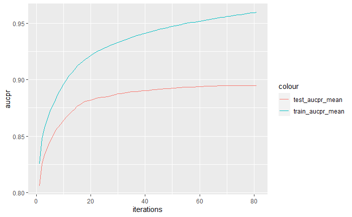

```r
ggplot(cross_validation$evaluation_log,aes(x=iter))+geom_line(aes(y=train_aucpr_mean,color="train_aucpr_mean"))+geom_line(aes(y=test_aucpr_mean,color="test_aucpr_mean"))+xlab("iterations")+ylab("aucpr")
```

We can see the model reached a test_aucpr_mean of about 0.9, which is a fairly good result.

### train the model

We can train the final model using the whole train data and use the model to make predictions on future unseen data

```r
model = xgb.train(data=dtrain,
                  nround=200,
                  objective = "binary:logistic",
                  eval_metric = "auc",
                  print_every_n = 10,
                  gamma=2)
```

### model performance on unseen data

The trained model can be used to predict on the previoulys hold out test data to see its performance unseen data. The confusion matrix is as follows. We can see the precision reaches 0.8378 and the recall reaches 0.8219, with a overall F1 score of 0.8297.

```r
test_preds = predict(model, dtest)
test_preds = ifelse(test_preds>0.5,1,0)
xg1_basic = confusionMatrix(as.factor(test_preds),tmp[test,]$dead60,positive="1",mode="prec_recall")
roc_basic = roc(tmp[test,]$dead60,test_preds, algorithm=2)
auc_basic = auc(roc_basic)
xg1_basic
```

```
Confusion Matrix and Statistics

          Reference
Prediction    0    1
         0 4222  376
         1  336 1735

               Accuracy : 0.8932
                 95% CI : (0.8856, 0.9006)
    No Information Rate : 0.6835
    P-Value [Acc > NIR] : <2e-16

                  Kappa : 0.752

 Mcnemar's Test P-Value : 0.1439

              Precision : 0.8378
                 Recall : 0.8219
                     F1 : 0.8297
             Prevalence : 0.3165
         Detection Rate : 0.2602
   Detection Prevalence : 0.3105
      Balanced Accuracy : 0.8741

       'Positive' Class : 1
```

### parameter tuning

Although the xgboost model witout parameter tuning already achieved rather good results, we can still do some parameter tuning to get better results. In this part, we use random parameter tuning to tune the model to get better results.

```r
set.seed(12345)
# params = makeParamSet(makeIntegerParam("max_depth",lower = 3L, upper=10L),
#                       makeNumericParam("min_child_weight"), lower=1L, upper=10L,
#                       makeNumericParam("subsample",lower=0.5,upper=1),
#                       makeNumericParam("colsample_bytree",lower=0.5,upper=1),
#                       makeIntegerParam("gamma"),lower=1L, upper=6L)
#best_model = NULL
#best_param = NULL
#best_val_aucpr = -1
for(i in 1:20){
  set.seed(i)
  param = list(max_depth = sample(3:10,1),
               eta = runif(1, 0.01, 0.3),
               subample = runif(1, 0.7, 1),
               colsample_bytree = runif(1, 0.5, 1),
               min_child_weight = sample(1:10,1),
               gamma = sample(1:6, 1))
  tmp_model = xgb.train(data=dtrain,
                  nround=400,
                  objective = "binary:logistic",
                  eval_metric = "aucpr",
                  print_every_n = 20,
                  early_stopping_rounds = 40,
                  params = param,
                  watchlist = list(train=dtrain,val=dval))
  if(as.numeric(strsplit(tmp_model$best_msg,":")[[1]][3])>best_val_aucpr){
    best_val_aucpr = as.numeric(strsplit(tmp_model$best_msg,":")[[1]][3])
    best_model = tmp_model
    best_param = param
  }

}
```

### re-train the model using the best parameters

```r
save(best_param, best_model, file="best_model_best_param.Rdata")
# final_model = xgb.train(data=dtrain,
#                   nround=256,
#                   objective = "binary:logistic",
#                   eval_metric = "aucpr",
#                   print_every_n = 10,
#                   params = best_param)
```

### model performance after re-training

```r
test_preds = predict(final_model, dtest)
test_preds = ifelse(test_preds>0.5,1,0)
xg1_tuned = confusionMatrix(as.factor(test_preds),tmp[test,]$dead60,positive="1",mode="prec_recall")
roc1 = roc(tmp[test,]$dead60,test_preds, algorithm=2)
auc1 = auc(roc1)
xg1_tuned
```

```
Confusion Matrix and Statistics

          Reference
Prediction    0    1
         0 4220  391
         1  338 1720

               Accuracy : 0.8907
                 95% CI : (0.883, 0.8981)
    No Information Rate : 0.6835
    P-Value [Acc > NIR] : < 2e-16

                  Kappa : 0.7456

 Mcnemar's Test P-Value : 0.05411

              Precision : 0.8358
                 Recall : 0.8148
                     F1 : 0.8251
             Prevalence : 0.3165
         Detection Rate : 0.2579
   Detection Prevalence : 0.3086
      Balanced Accuracy : 0.8703

       'Positive' Class : 1
```

### variable importance

We can plot the feature importance as follows. We can see the top three important features are age_at_baseline, dnr_flg_N, and length_of_stay_day_cnt.

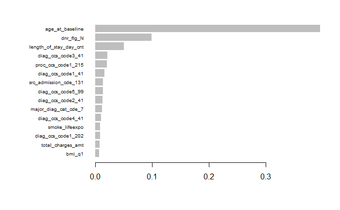

```r
important_matrix = xgboost::xgb.importance(colnames(tmp),model=final_model)
p = xgboost::xgb.plot.importance(important_matrix,top_n=15)
```

### checking the importance of co-morbiities.

We can see from the variable importance plot that co-morbidities do play a role in predicting the risk of death. The top important one diag_ccs_code3_41 represents “Cancer; other and unspecified primary”, which fairly matches our expectation.

## Weight of evidence for XGBoost model

In the previous model, all the categorical variables are converted to one-hot variables. This will erase the relationships among the different categories. In this part, we try to use the weight of evidence method to re-code the categorical variables. The weight of evidence tells the predictive power of an indenpedent variable in relation to the dependent variable. For a specific category $A$ of a variable $Var$, its $WOE$ is calculated as follows:

$$WOE = ln(\frac{
\%non-events}{
\% events}) =ln(\frac{nondeath\ within\ 60\ days\ }{deaths\ within\ 60\ days })$$

And then, for variable $Var$, its category $A$ is replaced by its $WOE$.

```r
new = df
new = as.data.table(new)
new = new[,.SD[which.max(discharge_dt)],by=participant_key]
new$days_to_death = as.numeric(new$date_of_death_dt - new$admission_dt)/30
new$dead60 = 0
new[new$days_to_death<60,"dead60"] = 1
new = new[,!to_null_vars, with=FALSE]
ref = new[train,]
for(each in to_onehot_vars){
        print(each)
        eval( parse(text=paste0("new$",each,"=replace_na(new$",each,',"NA_GROUP")')))
        eval( parse(text=paste0("a=table(ref$",each,",ref$dead60)")) )
        b=log((a[,"0"]+1)/(a[,"1"]+1))
        eval( parse(text=paste0("new$",each,"=b[match(new$",each,",names(b))]")) )

}
setnames(new, colnames(new), gsub("[-*]","",colnames(new)))
new[,dead60:=factor(dead60)]
new = as.data.frame(new)
```

```r
# set.seed(1234)
# new_split_desc = makeResampleDesc(method="Holdout",
#                               split=0.7,
#                               stratify=TRUE)
# new_classifier = makeClassifTask(id="deaths within 60 days after discharge",
#                              data = new,
#                              target = "dead60")
#
#
# new_split = makeResampleInstance(new_split_desc,task=new_classifier)
# new_train = new_split$train.inds[[1]]
# new_other = new_split$test.inds[[1]]
# new_val = sample(new_other,length(new_other)/2)
# test = setdiff(other, val)

new_dtrain = xgb.DMatrix(as.matrix(new[train,colnames(new)!="dead60"]),
                     label = as.numeric(new[train,]$dead60)-1)
new_dval = xgb.DMatrix(as.matrix(new[val,colnames(new)!="dead60"]),
                     label = as.numeric(new[val,]$dead60)-1)
new_dtest = xgb.DMatrix(as.matrix(new[test,colnames(new)!="dead60"]),
                     label = as.numeric(new[test,]$dead60)-1)
# new_cross_validation = xgb.cv(data=new_dtrain,
#                   nround=120,
#                   nfold=10,
#                   objective = "binary:logistic",
#                   eval_metric = "aucpr",
#                   early_stopping_rounds = 5,
#                   print_every_n = 5,
#                   prediction=TRUE)
```

```r
#ggplot(model$evaluation_log,aes(x=iter))+geom_line(aes(y=train_aucpr_mean,color="train_aucpr_mean"))+geom_line(aes(y=test_aucpr_mean,color="test_aucpr_mean"))+xlab("iterations")+ylab("aucpr")
set.seed(12345)
# params = makeParamSet(makeIntegerParam("max_depth",lower = 3L, upper=10L),
#                       makeNumericParam("min_child_weight"), lower=1L, upper=10L,
#                       makeNumericParam("subsample",lower=0.5,upper=1),
#                       makeNumericParam("colsample_bytree",lower=0.5,upper=1),
#                       makeIntegerParam("gamma"),lower=1L, upper=6L)
#new_best_model = NULL
#new_best_param = NULL
#new_best_val_aucpr = -1
for(i in 1:20){
  set.seed(i)
  param = list(max_depth = sample(3:10,1),
               eta = runif(1, 0.01, 0.3),
               subample = runif(1, 0.7, 1),
               colsample_bytree = runif(1, 0.5, 1),
               min_child_weight = sample(1:10,1),
               gamma = sample(1:6, 1))
  tmp_model = xgb.train(data=new_dtrain,
                  nround=400,
                  objective = "binary:logistic",
                  eval_metric = "aucpr",
                  print_every_n = 20,
                  early_stopping_rounds = 40,
                  params = param,
                  watchlist = list(train=new_dtrain,val=new_dval))
  if(as.numeric(strsplit(tmp_model$best_msg,":")[[1]][3])>new_best_val_aucpr){
    new_best_val_aucpr = as.numeric(strsplit(tmp_model$best_msg,":")[[1]][3])
    new_best_model = tmp_model
    new_best_param = param
  }

}
```

```r
new_test_preds = predict(new_best_model, new_dtest)
new_test_preds = ifelse(new_test_preds>0.5,1,0)
xg_new = confusionMatrix(as.factor(new_test_preds),new[test,]$dead60,positive="1",mode="prec_recall")
#roc_new = roc(new[test,]$dead60,new_test_preds, algorithm=2)
#auc_new = auc(roc_new)
xg_new
```

```
Confusion Matrix and Statistics

          Reference
Prediction    0    1
         0 4235  383
         1  314 1737

               Accuracy : 0.8955
                 95% CI : (0.8879, 0.9027)
    No Information Rate : 0.6821
    P-Value [Acc > NIR] : <2e-16

                  Kappa : 0.7569

 Mcnemar's Test P-Value : 0.01

              Precision : 0.8469
                 Recall : 0.8193
                     F1 : 0.8329
             Prevalence : 0.3179
         Detection Rate : 0.2605
   Detection Prevalence : 0.3075
      Balanced Accuracy : 0.8752

       'Positive' Class : 1
```

## Conlusion and Discussion

```r
#n = c("accuracy","Recall","Precision","F1")
a = c(xg1_basic[3]$overall[1],xg1_basic[4]$byClass[5],
      xg1_basic[4]$byClass[6],xg1_basic[4]$byClass[7])
b = c(xg1_tuned[3]$overall[1],xg1_tuned[4]$byClass[5],
      xg1_tuned[4]$byClass[6],xg1_tuned[4]$byClass[7])
c = c(xg_new[3]$overall[1],xg_new[4]$byClass[5],
      xg_new[4]$byClass[6],xg_new[4]$byClass[7])

res = data.frame(
           xgboost_default_paras=a,
           xgboost_parameter_tuning=b,
           xgboost_using_WOE=c)
res
```

|  | xgboost_default_paras | xgboost_parameter_tuning | xgboost_using_WOE |
| --- | --- | --- | --- |
| Accuracy | 0.8932374 | 0.8906883 | 0.8954866 |
| Precision | 0.8377595 | 0.8357629 | 0.8469039 |
| Recall | 0.8218854 | 0.8147797 | 0.8193396 |
| F1 | 0.8297465 | 0.8251379 | 0.8328938 |

We use random search to tune the parameter for xgboost using one-hot method only for 20 times, therefore “xgboost_parameter_tuning” may have worse results than “xgboost_default_paras”. However, “xgboost_using_WOE” is better than “xgboost_default_paras” or “xgboost_parameter_tuning”, showing that weight of evidence is more suitable to our case. Maybe we need more parameter tuning rounds